# Philippine Functional Disability

```python
import pandas as pd
from typing import Union
import numpy as np
import os
import warnings
import json
import plotly.express as px
import plotly.graph_objects as go
import cufflinks as cf
import re
from IPython.display import Image
warnings.filterwarnings("ignore")
from plotly.offline import download_plotlyjs, init_notebook_mode, plot, iplot
init_notebook_mode(connected=True)
cf.go_offline()
```

### Philippines:Functional Difficulty in the Philippines: Household Population Five Years Old and Over (2020 Census) Statistics Dataset

Base on the Republic Act No. 7277, known as the "Magna Carta for Disabled Persons," was enacted on March 24, 1992. This law aims to promote the rehabilitation, self-development, and integration of persons with disabilities (PWDs) into mainstream society. It ensures equal opportunities and access to education, employment, health services, and social integration for PWDs.

In 2016, Republic Act No. 10754 was enacted to expand the benefits and privileges of PWDs, further reinforcing the government's commitment to their welfare and inclusion.

• Data Source: https://psa.gov.ph/content/functional-difficulty-philippines-household-population-five-years-old-and-over-2020-census  
• Data from: https://data.humdata.org/dataset/philippines-functional-difficulty-census-2020  
• Data from: https://data.humdata.org/dataset/philippines-population-projection-2020-2025-admin3  
• Geojson file from: faeldon/philippines-json-maps

### Initialization

#### Loading datasets

Starting with the given metadata or the catalog of the dataset

```python
pwd=os.getcwd()
metadata=pd.read_csv(pwd+"/csv/metadata-philippines-functional-difficulty-census-2020.csv").dropna()
metadata
```

|  | Field | Label | Value |
| --- | --- | --- | --- |
| 0 | id | Dataset ID | 3895185b-e959-4c57-b6c6-2c1edbe2f439 |
| 1 | title | Title of Dataset | Philippines functional difficulty census 2020 |
| 2 | name | Dataset URL | philippines-functional-difficulty-census-2020 |
| 3 | notes | Description | Philippines: Household Population 5 Years Old ... |
| 4 | dataset_source | Source | PSA Census 2020 |
| 5 | organization | Contributor | OCHA Philippines |
| 6 | dataset_date | Reference Period | [2023-11-08T00:00:00 TO 2023-11-08T23:59:59] |
| 7 | last_modified | Updated | 2023-11-08T02:17:07.990144 |
| 8 | data_update_frequency | Expected Update Frequency | As needed |
| 9 | groups | Location | Philippines |
| 10 | license_title | License | Creative Commons Attribution International |
| 11 | methodology | Methodology | Census |
| 14 | tags | Tags | census, disability, sex and age disaggregated ... |
| 15 | resource_1_created | Created | 2023-11-08T02:17:08.348847 |
| 16 | resource_1_description | Description | Philippines: Household Population 5 Years Old ... |
| 17 | resource_1_format | File Format | XLSX |
| 18 | resource_1_download_url | Download URL | https://data.humdata.org/dataset/3895185b-e959... |
| 19 | resource_1_id | Resource ID | 99744acf-5ee2-4a5b-b2fa-d13f60be1ede |
| 20 | resource_1_last_modified | Updated | 2023-11-08T02:17:07.990144 |
| 21 | resource_1_metadata_modified | Metadata Updated | 2023-11-08T07:40:15.894148 |
| 22 | resource_1_microdata | Microdata | False |
| 23 | resource_1_dataset_id | Dataset ID | 3895185b-e959-4c57-b6c6-2c1edbe2f439 |
| 24 | resource_1_resource_type | Resource Type | file.upload |
| 25 | resource_1_name | Resource Name | HH Functional Difficulty Severity Age Group Mu... |
| 26 | resource_1_mimetype | MIME Type | application/vnd.openxmlformats-officedocument.... |
| 27 | resource_1_size | Size | 15.0M |

```python
dict_metadata = dict(zip(metadata['Label'].values, metadata['Value'].values))
print(dict_metadata['Size'])
```

```
15.0M
```

```python
dataset=pd.read_csv(pwd+"/csv/functional_difficulty.csv",encoding="ISO-8859-1")
dataset.head()
```

|  | Region | Province | Mun | RegCode_New | RegCode_Old | ProvCode_New | ProvCode_Old | MunCode_New | MunCode_Old | Disability | ... | Age 35 - 39 | Age 40 - 44 | Age 45 - 49 | Age 50 - 54 | Age 55 - 59 | Age 60 - 64 | Age 65 - 69 | Age 70 - 74 | Age 75 - 79 | Age 80 years and over |
| --- | --- | --- | --- | --- | --- | --- | --- | --- | --- | --- | --- | --- | --- | --- | --- | --- | --- | --- | --- | --- | --- |
| 0 | BANGSAMORO AUTONOMOUS REGION IN MUSLIM MINDANA... | BASILAN | CITY OF LAMITAN (CAPITAL) | PH1900000000 | PH150000000 | PH1900700000 | PH150700000 | PH1900702000 | PH150702000 | Seeing even if wearing eyeglasses | ... | 91 | 162 | 300 | 552 | 469 | 487 | 367 | 294 | 197 | 231 |
| 1 | BANGSAMORO AUTONOMOUS REGION IN MUSLIM MINDANA... | BASILAN | CITY OF LAMITAN (CAPITAL) | PH1900000000 | PH150000000 | PH1900700000 | PH150700000 | PH1900702000 | PH150702000 | Seeing even if wearing eyeglasses | ... | 84 | 152 | 292 | 540 | 453 | 470 | 356 | 284 | 181 | 206 |
| 2 | BANGSAMORO AUTONOMOUS REGION IN MUSLIM MINDANA... | BASILAN | CITY OF LAMITAN (CAPITAL) | PH1900000000 | PH150000000 | PH1900700000 | PH150700000 | PH1900702000 | PH150702000 | Seeing even if wearing eyeglasses | ... | 0 | 4 | 4 | 11 | 11 | 13 | 10 | 10 | 14 | 19 |
| 3 | BANGSAMORO AUTONOMOUS REGION IN MUSLIM MINDANA... | BASILAN | CITY OF LAMITAN (CAPITAL) | PH1900000000 | PH150000000 | PH1900700000 | PH150700000 | PH1900702000 | PH150702000 | Seeing even if wearing eyeglasses | ... | 7 | 6 | 4 | 1 | 5 | 4 | 1 | 0 | 2 | 6 |
| 4 | BANGSAMORO AUTONOMOUS REGION IN MUSLIM MINDANA... | BASILAN | CITY OF LAMITAN (CAPITAL) | PH1900000000 | PH150000000 | PH1900700000 | PH150700000 | PH1900702000 | PH150702000 | Seeing even if wearing eyeglasses | ... | 46 | 74 | 131 | 281 | 254 | 235 | 174 | 127 | 82 | 75 |

5 rows × 29 columns

#### Data Cleaning And Transforming data

Drop Any None 'All', 'Mild', 'Moderate', 'Severe' in DataFrame Status Column

```python
dataset.dropna().drop_duplicates()
dataset=dataset.drop(dataset[~dataset["Status"].isin(['All', 'Mild', 'Moderate', 'Severe'])].index)
```

Summing up the ages to (5-19,20-34,35–54,55-80+) for easier comparasion later

```python
age={"Age: 5-19":["Age 5-9","Age 10-14","Age 15 - 19"],
                        "Age: 20-34":["Age 20 - 24","Age 25 - 29","Age 30 - 34"],
                        "Age: 35–54":["Age 35 - 39","Age 40 - 44","Age 45 - 49","Age 50 - 54"],
                        "Age: 55-80+":["Age 55 - 59","Age 60 - 64","Age 65 - 69","Age 70 - 74","Age 75 - 79",'Age 80 years and over']
                        }
for col_age,age_value in age.items():
    existing=[col for col in age_value if col in dataset.columns]
    dataset[col_age]=dataset[age_value].sum(axis=1)
dataset.head(3)
```

|  | Region | Province | Mun | RegCode_New | RegCode_Old | ProvCode_New | ProvCode_Old | MunCode_New | MunCode_Old | Disability | ... | Age 55 - 59 | Age 60 - 64 | Age 65 - 69 | Age 70 - 74 | Age 75 - 79 | Age 80 years and over | Age: 5-19 | Age: 20-34 | Age: 35–54 | Age: 55-80+ |
| --- | --- | --- | --- | --- | --- | --- | --- | --- | --- | --- | --- | --- | --- | --- | --- | --- | --- | --- | --- | --- | --- |
| 0 | BANGSAMORO AUTONOMOUS REGION IN MUSLIM MINDANA... | BASILAN | CITY OF LAMITAN (CAPITAL) | PH1900000000 | PH150000000 | PH1900700000 | PH150700000 | PH1900702000 | PH150702000 | Seeing even if wearing eyeglasses | ... | 469 | 487 | 367 | 294 | 197 | 231 | 100 | 146 | 1105 | 2045 |
| 1 | BANGSAMORO AUTONOMOUS REGION IN MUSLIM MINDANA... | BASILAN | CITY OF LAMITAN (CAPITAL) | PH1900000000 | PH150000000 | PH1900700000 | PH150700000 | PH1900702000 | PH150702000 | Seeing even if wearing eyeglasses | ... | 453 | 470 | 356 | 284 | 181 | 206 | 74 | 109 | 1068 | 1950 |
| 2 | BANGSAMORO AUTONOMOUS REGION IN MUSLIM MINDANA... | BASILAN | CITY OF LAMITAN (CAPITAL) | PH1900000000 | PH150000000 | PH1900700000 | PH150700000 | PH1900702000 | PH150702000 | Seeing even if wearing eyeglasses | ... | 11 | 13 | 10 | 10 | 14 | 19 | 3 | 5 | 19 | 77 |

3 rows × 33 columns

Changing the content of Disability Description for to be more readable and clarity

```python
dataset["Disability"]=dataset["Disability"].str.strip()
rename={"Visual Disability":'Seeing even if wearing eyeglasses',
                        "Hearing Disability":'Hearing even if using a hearing aid',
                        "Mobility Disability":'Walking or climbing steps',
                        "Cognitive Disability":'Remembering or concentrating',
                        "Self-Care Disability":'Self-caring (washing all over or dressing)',
                        "Communication Disability":"Communicating"}
for Disability_new,Disability_old in rename.items():
   check=[col for col in Disability_old if col in dataset]
   dataset["Disability"].replace({Disability_old:Disability_new},inplace=True)
dataset["Disability"].unique()
```

```
array(['Visual Disability', 'Hearing Disability', 'Mobility Disability',
       'Cognitive Disability', 'Self-Care Disability',
       'Communication Disability'], dtype=object)
```

#### data filtering

Including only the geographical information and the columns that will be use later on

```python
code_to_keep = [x for x in dataset.columns if not re.match(r"^.*(Mun|MunCode_Old|New)$", x)]
dataset=dataset[code_to_keep]
dataset.head(3)
```

|  | Region | Province | RegCode_Old | ProvCode_Old | Disability | Sex | Status | Household Population 5 Years Old and Over with Functional Difficulty | Age 5-9 | Age 10-14 | ... | Age 55 - 59 | Age 60 - 64 | Age 65 - 69 | Age 70 - 74 | Age 75 - 79 | Age 80 years and over | Age: 5-19 | Age: 20-34 | Age: 35–54 | Age: 55-80+ |
| --- | --- | --- | --- | --- | --- | --- | --- | --- | --- | --- | --- | --- | --- | --- | --- | --- | --- | --- | --- | --- | --- |
| 0 | BANGSAMORO AUTONOMOUS REGION IN MUSLIM MINDANA... | BASILAN | PH150000000 | PH150700000 | Visual Disability | Both Sexes | All | 3396 | 45 | 30 | ... | 469 | 487 | 367 | 294 | 197 | 231 | 100 | 146 | 1105 | 2045 |
| 1 | BANGSAMORO AUTONOMOUS REGION IN MUSLIM MINDANA... | BASILAN | PH150000000 | PH150700000 | Visual Disability | Both Sexes | Mild | 3201 | 32 | 24 | ... | 453 | 470 | 356 | 284 | 181 | 206 | 74 | 109 | 1068 | 1950 |
| 2 | BANGSAMORO AUTONOMOUS REGION IN MUSLIM MINDANA... | BASILAN | PH150000000 | PH150700000 | Visual Disability | Both Sexes | Moderate | 104 | 1 | 1 | ... | 11 | 13 | 10 | 10 | 14 | 19 | 3 | 5 | 19 | 77 |

3 rows × 28 columns

```python
age_to_keep = [x for x in dataset.columns if not re.match(r"^(\bAge \b).*", x)]
dataset=dataset[age_to_keep]
dataset.head(3)
```

|  | Region | Province | RegCode_Old | ProvCode_Old | Disability | Sex | Status | Household Population 5 Years Old and Over with Functional Difficulty | Age: 5-19 | Age: 20-34 | Age: 35–54 | Age: 55-80+ |
| --- | --- | --- | --- | --- | --- | --- | --- | --- | --- | --- | --- | --- |
| 0 | BANGSAMORO AUTONOMOUS REGION IN MUSLIM MINDANA... | BASILAN | PH150000000 | PH150700000 | Visual Disability | Both Sexes | All | 3396 | 100 | 146 | 1105 | 2045 |
| 1 | BANGSAMORO AUTONOMOUS REGION IN MUSLIM MINDANA... | BASILAN | PH150000000 | PH150700000 | Visual Disability | Both Sexes | Mild | 3201 | 74 | 109 | 1068 | 1950 |
| 2 | BANGSAMORO AUTONOMOUS REGION IN MUSLIM MINDANA... | BASILAN | PH150000000 | PH150700000 | Visual Disability | Both Sexes | Moderate | 104 | 3 | 5 | 19 | 77 |

Transforming numeracal into int64 for later calculation

```python
to_numeric = [x for x in dataset.columns if re.match(r"^(\bAge|Ho).*", x)]
for x in to_numeric:
    dataset[x]=pd.to_numeric(dataset[x],errors="coerce").fillna(0).astype("int64")
to_numeric
```

```
['Household Population 5 Years Old and Over with Functional Difficulty',
 'Age: 5-19',
 'Age: 20-34',
 'Age: 35–54',
 'Age: 55-80+']
```

```python
dataset.info()
```

```
<class 'pandas.core.frame.DataFrame'>
Index: 118286 entries, 0 to 118290
Data columns (total 12 columns):
 #   Column                                                                Non-Null Count   Dtype
---  ------                                                                --------------   -----
 0   Region                                                                118286 non-null  object
 1   Province                                                              118286 non-null  object
 2   RegCode_Old                                                           118286 non-null  object
 3   ProvCode_Old                                                          117710 non-null  object
 4   Disability                                                            118286 non-null  object
 5   Sex                                                                   118286 non-null  object
 6   Status                                                                118286 non-null  object
 7   Household Population 5 Years Old and Over with Functional Difficulty  118286 non-null  int64
 8   Age: 5-19                                                             118286 non-null  int64
 9   Age: 20-34                                                            118286 non-null  int64
 10  Age: 35–54                                                            118286 non-null  int64
 11  Age: 55-80+                                                           118286 non-null  int64
dtypes: int64(5), object(7)
memory usage: 11.7+ MB
```

```python
dataset.describe()
```

|  | Household Population 5 Years Old and Over with Functional Difficulty | Age: 5-19 | Age: 20-34 | Age: 35–54 | Age: 55-80+ |
| --- | --- | --- | --- | --- | --- |
| count | 118286.000000 | 118286.000000 | 118286.000000 | 118286.000000 | 118286.000000 |
| mean | 453.243748 | 23.372233 | 33.631571 | 111.690817 | 284.551697 |
| std | 2026.629044 | 109.886112 | 220.168449 | 646.899337 | 1103.016444 |
| min | 0.000000 | 0.000000 | 0.000000 | 0.000000 | 0.000000 |
| 25% | 30.000000 | 3.000000 | 3.000000 | 4.000000 | 16.000000 |
| 50% | 93.000000 | 8.000000 | 8.000000 | 13.000000 | 59.000000 |
| 75% | 337.000000 | 19.000000 | 22.000000 | 56.000000 | 231.000000 |
| max | 158468.000000 | 9785.000000 | 20600.000000 | 51030.000000 | 94941.000000 |

### Loading geojson file

```python
geolocation = json.load(open(pwd+r'/geojson/regions/regions.0.01.json'))
```

Creating a dictionary for Geojson for easy calls for Choroleth Visualization

```python
dic_regcode={}
for x in geolocation["features"]:
    x['id']=x["properties"]["ADM1_PCODE"]
    dic_regcode[x["properties"]["ADM1_EN"]]=x["id"]
dic_regcode.pop('Negros Island Region','PH180000000')
dic_regcode
```

```
{'Autonomous Region in Muslim Mindanao': 'PH150000000',
 'Cordillera Administrative Region': 'PH140000000',
 'National Capital Region': 'PH130000000',
 'Region I': 'PH010000000',
 'Region II': 'PH020000000',
 'Region III': 'PH030000000',
 'Region IV-A': 'PH040000000',
 'Region IV-B': 'PH170000000',
 'Region IX': 'PH090000000',
 'Region V': 'PH050000000',
 'Region VI': 'PH060000000',
 'Region VII': 'PH070000000',
 'Region VIII': 'PH080000000',
 'Region X': 'PH100000000',
 'Region XI': 'PH110000000',
 'Region XII': 'PH120000000',
 'Region XIII': 'PH160000000'}
```

### Loading up Population Dataset

I've already clean and process this data in excel

```python
total_population=pd.read_csv(pwd + r"/csv/ph_population_2020.csv")
total_population.head()
```

|  | Region | Province | Province_pcode | Population |
| --- | --- | --- | --- | --- |
| 0 | Region I (Ilocos Region) | ILOCOS NORTE | PH012800000 | 1823 |
| 1 | Region I (Ilocos Region) | ILOCOS NORTE | PH012800000 | 32778 |
| 2 | Region I (Ilocos Region) | ILOCOS NORTE | PH012800000 | 32218 |
| 3 | Region I (Ilocos Region) | ILOCOS NORTE | PH012800000 | 14954 |
| 4 | Region I (Ilocos Region) | ILOCOS NORTE | PH012800000 | 56248 |

### Groupbys

grouping by "Region","Sex","Disability","Status" where its not equal to "Both Sexes" and "Status" for more pricise analysis

```python
gender_severety=(dataset.loc[(dataset["Sex"] != 'Both Sexes')& (dataset["Status"] != 'All')]
                 .groupby(["Region","Province","Sex","Disability","Status"],as_index=False)
                 ["Household Population 5 Years Old and Over with Functional Difficulty"]
                 .sum())
```

Grouping by "Region","Province" since its notsum up for each provice and region

```python
total_population_region=total_population.groupby(["Region","Province"],as_index=False)["Population"].sum()
total_population_region["Region"]=total_population_region["Region"].str.strip("")
total_population_region.head(3)
```

|  | Region | Province | Population |
| --- | --- | --- | --- |
| 0 | BANGSAMORO AUTONOMOUS REGION IN MUSLIM MINDANA... | BASILAN | 386697 |
| 1 | BANGSAMORO AUTONOMOUS REGION IN MUSLIM MINDANA... | LANAO DEL SUR | 1146287 |
| 2 | BANGSAMORO AUTONOMOUS REGION IN MUSLIM MINDANA... | MAGUINDANAO | 1323051 |

Doing this group by becuase i want to only get the "Both Sexes" of Mild,Severe,Moderate Status

```python
disability_by_region = (
    dataset.loc[(dataset["Sex"] == "Both Sexes")& (dataset["Status"] != "All") ]
    .groupby(["Disability", "Region","Status","RegCode_Old","Province","ProvCode_Old"],
             as_index=False)["Household Population 5 Years Old and Over with Functional Difficulty"].sum())
```

This is for Visualization in plotly so that it does'nt give me line in the bar itself😢

```python
population=total_population.groupby(["Region"],as_index=False)["Population"].sum()
most_common_disability_region=dataset.groupby(["Region","Disability"],as_index=False)["Household Population 5 Years Old and Over with Functional Difficulty"].sum()
```

Specifying the Age columns for later Visualization

```python
ages_groupby=(dataset.loc[(dataset["Sex"] == "Both Sexes") & (dataset["Status"] == "All")]
    .groupby(["Region","Province","Disability"], as_index=False)[['Age: 5-19',"Age: 20-34","Age: 35–54","Age: 55-80+","Household Population 5 Years Old and Over with Functional Difficulty"]]
    .sum()
    )
```

### Merges

Merging dataset with total_population to getting average person with Disability per Region and Province and using log10 since some its throwing off the charts

```python
total_disability_population=pd.merge(disability_by_region,total_population_region,on=["Region","Province"])
total_disability_population["Person affected by disability per 100k"]=np.ceil(total_disability_population['Household Population 5 Years Old and Over with Functional Difficulty']
                                                                       /total_disability_population['Population']
                                                                       * 100000)
total_disability_population["scale affected"]=np.log10(total_disability_population["Person affected by disability per 100k"])
```

This is for getting the average person with disabilty in Ages columns and using melt for Pie chart Visualization

```python
age_regional_disibality=pd.merge(ages_groupby,total_population_region,on=["Region","Province"])
age_group = {
    "Age: 5-19": "Age: 5-19",
    "Age: 20-34": "Age: 20-34",
    "Age: 35–54": "Age: 35–54",
    "Age: 55-80+": "Age: 55-80+"
}
for age_label, age_column in age_group.items():
     age_regional_disibality[age_label] = np.ceil(age_regional_disibality[age_column] /
                                                                                age_regional_disibality['Population'] * 100000)
age_to_viz=age_regional_disibality.melt(id_vars=["Disability","Region","Population"],value_vars=list(age_group.values())
                                        ,value_name="age affection",
                                        var_name="age/ave_affected").drop_duplicates()
group_age_to_viz=age_to_viz.groupby("age/ave_affected",as_index=False)["age affection"].sum()
age_regional_disibality.head(3)
```

|  | Region | Province | Disability | Age: 5-19 | Age: 20-34 | Age: 35–54 | Age: 55-80+ | Household Population 5 Years Old and Over with Functional Difficulty | Population |
| --- | --- | --- | --- | --- | --- | --- | --- | --- | --- |
| 0 | BANGSAMORO AUTONOMOUS REGION IN MUSLIM MINDANA... | BASILAN | Cognitive Disability | 39.0 | 38.0 | 79.0 | 317.0 | 1820 | 386697 |
| 1 | BANGSAMORO AUTONOMOUS REGION IN MUSLIM MINDANA... | BASILAN | Communication Disability | 85.0 | 65.0 | 72.0 | 191.0 | 1587 | 386697 |
| 2 | BANGSAMORO AUTONOMOUS REGION IN MUSLIM MINDANA... | BASILAN | Hearing Disability | 43.0 | 43.0 | 139.0 | 611.0 | 3226 | 386697 |

Since i have no accurate population for Gender i just cut the population in half to get the average of gender

```python
gender_serverity_disability=pd.merge(gender_severety,total_population_region,on=["Region","Province"]).assign(population=lambda x:x["Population"]/2)
gender_serverity_disability["Gender affected by disability per 100k"]=(gender_serverity_disability["Household Population 5 Years Old and Over with Functional Difficulty"]/(gender_serverity_disability['Population']/2)*100000).astype(int)

gender_serverity_disability.rename(columns={"population":"Gender Population"},inplace=True)

#drop Population since its not needed and making the pivot table look not so good
gender_serverity_disability.drop(columns="Population",inplace=True)
gender_serverity_disability.head(3)
```

|  | Region | Province | Sex | Disability | Status | Household Population 5 Years Old and Over with Functional Difficulty | Gender Population | Gender affected by disability per 100k |
| --- | --- | --- | --- | --- | --- | --- | --- | --- |
| 0 | BANGSAMORO AUTONOMOUS REGION IN MUSLIM MINDANA... | BASILAN | Female | Cognitive Disability | Mild | 881 | 193348.5 | 455 |
| 1 | BANGSAMORO AUTONOMOUS REGION IN MUSLIM MINDANA... | BASILAN | Female | Cognitive Disability | Moderate | 97 | 193348.5 | 50 |
| 2 | BANGSAMORO AUTONOMOUS REGION IN MUSLIM MINDANA... | BASILAN | Female | Cognitive Disability | Severe | 29 | 193348.5 | 14 |

#### Pivot table

Creating pivot table for easy to read DataFrame for streamlit

```python
age_regional_disibality_pivot=age_regional_disibality.pivot_table(index=["Region","Province"],columns="Disability").head(5)
age_regional_disibality_pivot.head(4)
```

| Region | Disability Province | Age: 20-34 Cognitive Disability | Age: 20-34 Communication Disability | Age: 20-34 Hearing Disability | Age: 20-34 Mobility Disability | Age: 20-34 Self-Care Disability | Age: 20-34 Visual Disability | Age: 35–54 Cognitive Disability | Age: 35–54 Communication Disability | Age: 35–54 Hearing Disability | Age: 35–54 Mobility Disability | ... | Household Population 5 Years Old and Over with Functional Difficulty Hearing Disability | Household Population 5 Years Old and Over with Functional Difficulty Mobility Disability | Household Population 5 Years Old and Over with Functional Difficulty Self-Care Disability | Household Population 5 Years Old and Over with Functional Difficulty Visual Disability | Population Cognitive Disability | Population Communication Disability | Population Hearing Disability | Population Mobility Disability | Population Self-Care Disability | Population Visual Disability |
| --- | --- | --- | --- | --- | --- | --- | --- | --- | --- | --- | --- | --- | --- | --- | --- | --- | --- | --- | --- | --- | --- | --- |
| BANGSAMORO AUTONOMOUS REGION IN MUSLIM MINDANAO (BARMM) | BASILAN | 38.0 | 65.0 | 43.0 | 43.0 | 34.0 | 99.0 | 79.0 | 72.0 | 139.0 | 161.0 | ... | 3226.0 | 3161.0 | 1377.0 | 7490.0 | 386697.0 | 386697.0 | 386697.0 | 386697.0 | 386697.0 | 386697.0 |
|  | LANAO DEL SUR | 131.0 | 162.0 | 122.0 | 112.0 | 102.0 | 328.0 | 674.0 | 271.0 | 678.0 | 691.0 | ... | 31475.0 | 30461.0 | 20571.0 | 67216.0 | 1146287.0 | 1146287.0 | 1146287.0 | 1146287.0 | 1146287.0 | 1146287.0 |
|  | MAGUINDANAO | 46.0 | 77.0 | 49.0 | 46.0 | 47.0 | 111.0 | 187.0 | 133.0 | 245.0 | 257.0 | ... | 14416.0 | 14807.0 | 10102.0 | 30314.0 | 1323051.0 | 1323051.0 | 1323051.0 | 1323051.0 | 1323051.0 | 1323051.0 |
|  | SULU | 6.0 | 37.0 | 9.0 | 9.0 | 6.0 | 53.0 | 31.0 | 40.0 | 58.0 | 58.0 | ... | 3273.0 | 3254.0 | 1535.0 | 6008.0 | 913590.0 | 913590.0 | 913590.0 | 913590.0 | 913590.0 | 913590.0 |

4 rows × 36 columns

```python
gender_serverity_disability_pivot=gender_serverity_disability.pivot_table(index=["Region","Sex","Status","Gender Population","Province"],columns=["Disability"])
gender_serverity_disability_pivot.head(3)
```

| Region | Sex | Status | Gender Population | Disability Province | Gender affected by disability per 100k Cognitive Disability | Gender affected by disability per 100k Communication Disability | Gender affected by disability per 100k Hearing Disability | Gender affected by disability per 100k Mobility Disability | Gender affected by disability per 100k Self-Care Disability | Gender affected by disability per 100k Visual Disability | Household Population 5 Years Old and Over with Functional Difficulty Cognitive Disability | Household Population 5 Years Old and Over with Functional Difficulty Communication Disability | Household Population 5 Years Old and Over with Functional Difficulty Hearing Disability | Household Population 5 Years Old and Over with Functional Difficulty Mobility Disability | Household Population 5 Years Old and Over with Functional Difficulty Self-Care Disability | Household Population 5 Years Old and Over with Functional Difficulty Visual Disability |
| --- | --- | --- | --- | --- | --- | --- | --- | --- | --- | --- | --- | --- | --- | --- | --- | --- |
| BANGSAMORO AUTONOMOUS REGION IN MUSLIM MINDANAO (BARMM) | Female | Mild | 193348.5 | BASILAN | 455.0 | 297.0 | 794.0 | 760.0 | 313.0 | 1904.0 | 881.0 | 575.0 | 1536.0 | 1470.0 | 606.0 | 3683.0 |
|  |  |  | 206845.0 | TAWI-TAWI | 561.0 | 237.0 | 857.0 | 736.0 | 276.0 | 1448.0 | 1162.0 | 491.0 | 1773.0 | 1524.0 | 571.0 | 2997.0 |
|  |  |  | 456795.0 | SULU | 219.0 | 174.0 | 364.0 | 358.0 | 170.0 | 541.0 | 1004.0 | 798.0 | 1664.0 | 1636.0 | 778.0 | 2474.0 |

```python
top_disability_region=ages_groupby.pivot_table(index=["Region","Province"],aggfunc="max")
top_disability_region.head(4)
```

| Region | Province | Age: 20-34 | Age: 35–54 | Age: 5-19 | Age: 55-80+ | Disability | Household Population 5 Years Old and Over with Functional Difficulty |
| --- | --- | --- | --- | --- | --- | --- | --- |
| BANGSAMORO AUTONOMOUS REGION IN MUSLIM MINDANAO (BARMM) | BASILAN | 380 | 2386 | 327 | 4426 | Visual Disability | 7490 |
|  | COTABATO CITY (NOT A PROVINCE) | 236 | 1888 | 270 | 3799 | Visual Disability | 5746 |
|  | LANAO DEL SUR | 3752 | 25103 | 5427 | 36388 | Visual Disability | 67216 |
|  | MAGUINDANAO | 1464 | 10376 | 2470 | 17483 | Visual Disability | 30314 |

### Functions

Creating a function that create and save plot since i cant plots does'nt show as html and to also use for readme

```python
def to_image(fig, image_name):
    output_folder = os.path.join(os.getcwd(), 'images')
    if not os.path.exists(output_folder):
        os.makedirs(output_folder)
    image_path = os.path.join(output_folder, f'{image_name}.png')
    fig.write_image(image_path,width=1200, height=800, scale=2)
    return Image(filename=image_path)
```

Create a function for file checking

```python
def check_file(reg_prov_fol,file):
     check=os.path.join(reg_prov_fol,file)

     if os.path.exists(check):
               return json.load(open(check,"r"))
     else:
                 print(f"File {check} dont exist")
```

Create a custom groupby function so that simple Charts can show Different Columns

```python
def groupbys(group:Union[str, list[str]]):
    return dataset.loc[(dataset["Sex"] != "Both Sexes")& (dataset["Status"] != "All") ].groupby(group,
             as_index=False)["Household Population 5 Years Old and Over with Functional Difficulty"].sum()
groupbys(["Region","Disability","Province"])
```

|  | Region | Disability | Province | Household Population 5 Years Old and Over with Functional Difficulty |
| --- | --- | --- | --- | --- |
| 0 | BANGSAMORO AUTONOMOUS REGION IN MUSLIM MINDANA... | Cognitive Disability | BASILAN | 1820 |
| 1 | BANGSAMORO AUTONOMOUS REGION IN MUSLIM MINDANA... | Cognitive Disability | COTABATO CITY (NOT A PROVINCE) | 1662 |
| 2 | BANGSAMORO AUTONOMOUS REGION IN MUSLIM MINDANA... | Cognitive Disability | LANAO DEL SUR | 27335 |
| 3 | BANGSAMORO AUTONOMOUS REGION IN MUSLIM MINDANA... | Cognitive Disability | MAGUINDANAO | 10660 |
| 4 | BANGSAMORO AUTONOMOUS REGION IN MUSLIM MINDANA... | Cognitive Disability | SULU | 1973 |
| ... | ... | ... | ... | ... |
| 517 | Region XIII (Caraga) | Visual Disability | AGUSAN DEL NORTE | 35496 |
| 518 | Region XIII (Caraga) | Visual Disability | AGUSAN DEL SUR | 37034 |
| 519 | Region XIII (Caraga) | Visual Disability | DINAGAT ISLANDS | 7885 |
| 520 | Region XIII (Caraga) | Visual Disability | SURIGAO DEL NORTE | 32694 |
| 521 | Region XIII (Caraga) | Visual Disability | SURIGAO DEL SUR | 45359 |

522 rows × 4 columns

This functions takes care of the layouting of Choroleth and other Charts and graphs including the coloring(did'nt include in the function since i dont want to put a another argument in fucntions)

```python
#this is for the coloring of Visualizations
color_scale_values = np.linspace(0, 1, len(age_to_viz["age affection"]))
colors = px.colors.sample_colorscale("Plasma", color_scale_values)


def fig_layout(fig,var:str):
        figchorolet=fig.update_layout(
        coloraxis=dict(colorbar=dict(orientation='h', y=0.9)),
        coloraxis_colorbar = dict(title = 'Disability'),
        margin={"r":0,"t":0,"l":0,"b":0},
        paper_bgcolor = 'rgba(0,0,0,0)',
        plot_bgcolor = 'rgba(0,0,0,0)',
        geo = dict(bgcolor = 'rgba(0,0,0,0)', ),
        modebar_bgcolor = 'rgba(0,0,0,0)',
        modebar_color = '#6d0006',
        modebar_activecolor = '#323140',
        modebar_orientation = 'v')

        figviz=fig.update_layout(uniformtext_minsize=10, uniformtext_mode="hide",
                        margin=dict(autoexpand=False,l=50,r=200,t=30),autosize=True,showlegend=True,
                        title_font=dict(color="#bae03a"),
                          font=dict(color="#ab22bd"),
                        paper_bgcolor = 'rgba(0,0,0,0)',
                        plot_bgcolor = 'rgba(0,0,0,0)',
                       coloraxis=dict(colorbar=dict(orientation='v', y=0.5)))

        if var == "choro":
                return figchorolet
        elif var == "viz":
                return figviz
        else:
                return "somehting wrong"
```

### Visualization with Plotly

#### Choroleth

Created a simple Region Choroleth where you can change the status and view in different status

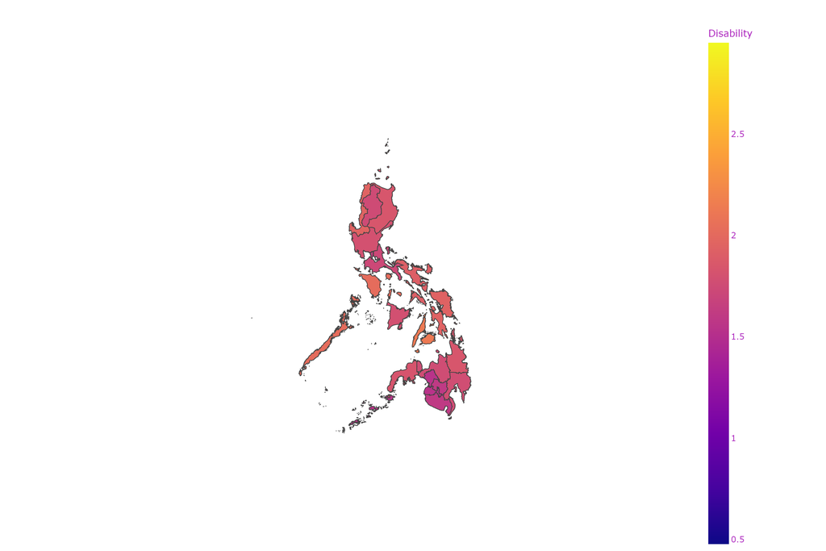

```python
var="choro"
def region_figure(x:str):# -> Any:
    value=total_disability_population.loc[total_disability_population["Status"]==(x).capitalize().strip()]
    folder_path="geojson/regions"
    prov_file="regions.0.01.json"
    if not check_file(folder_path,prov_file):
       pass
    else:
        fig = px.choropleth(
                data_frame = value,
                geojson = check_file(folder_path,prov_file),
                featureidkey = 'properties.ADM1_PCODE',
                locations = "RegCode_Old",
            color="scale affected",
            center={"lat":12.8797,"lon":121.7740},
                hover_data="Person affected by disability per 100k",
                    hover_name="Region",color_continuous_scale=colors)
        fig.update_geos(fitbounds="locations",visible=False)
        fig_layout(fig,var)
        return to_image(fig,"Choroleth_region")
region_figure(x="severe")
```

Created a simple Province choroleth where you can change the status and regions of which user wish to view

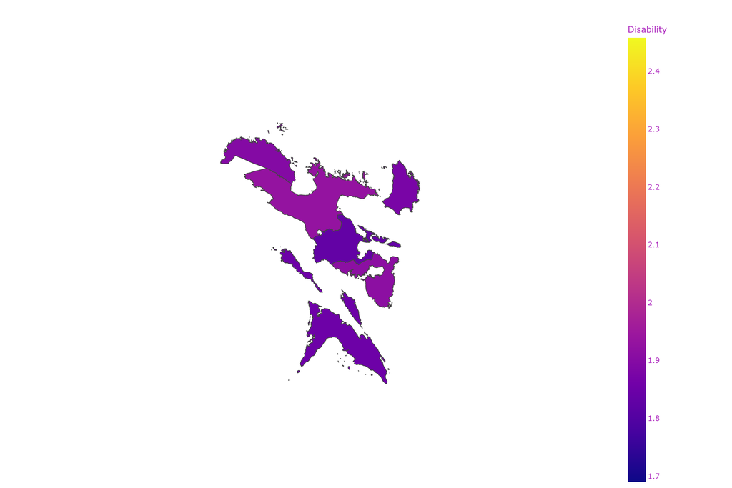

```python
def province_figure(y,x):# -> An
    folder_path="geojson/provinces"
    prov_file=f"provinces-region-{dic_regcode[y].lower()}.0.01.json"
    value=total_disability_population.loc[(total_disability_population["Status"]==(x).capitalize().strip())
                                           & (total_disability_population["RegCode_Old"]== dic_regcode[y])]

    fig = px.choropleth(
                data_frame = value,
                geojson =  check_file(folder_path,prov_file),
                featureidkey = 'properties.ADM2_PCODE',
                locations = "ProvCode_Old",
            color="scale affected",
              center={"lat":12.8797,"lon":121.7740},
                hover_data="Person affected by disability per 100k",
                hover_name="Province",color_continuous_scale=colors)
    fig.update_geos(fitbounds="locations",visible=False)
    fig_layout(fig,var)
    return to_image(fig,"Choroleth_province")
province_figure(y="Region V",x="severe")
```

#### Bar

Simple Bar chart for Disability Distribution

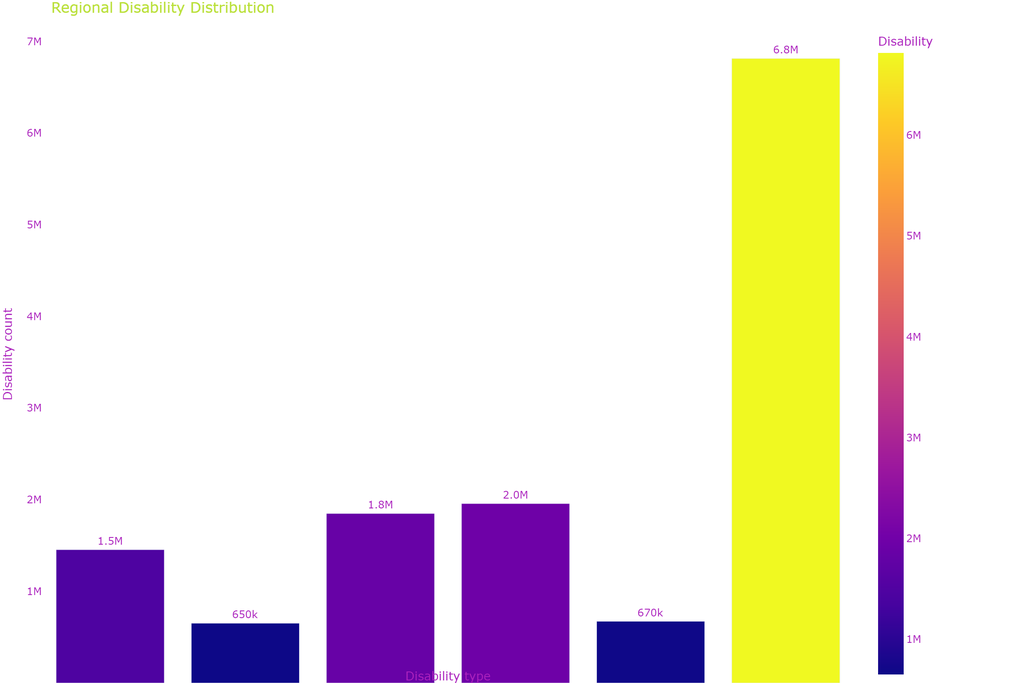

```python
viz="viz"
groupcontroler="Disability"
figbar=px.bar(groupbys(groupcontroler),x=groupcontroler,y="Household Population 5 Years Old and Over with Functional Difficulty",
       color="Household Population 5 Years Old and Over with Functional Difficulty",title="Regional Disability Distribution",
       labels={"Disability":"Disability type",
               "Household Population 5 Years Old and Over with Functional Difficulty":"Disability count"},
               text="Household Population 5 Years Old and Over with Functional Difficulty",color_continuous_scale=colors
               )
figbar.update_traces(texttemplate="%{text:.2s}",textposition="outside")
fig_layout(figbar,viz)
to_image(figbar,"Bar_chart1")
```

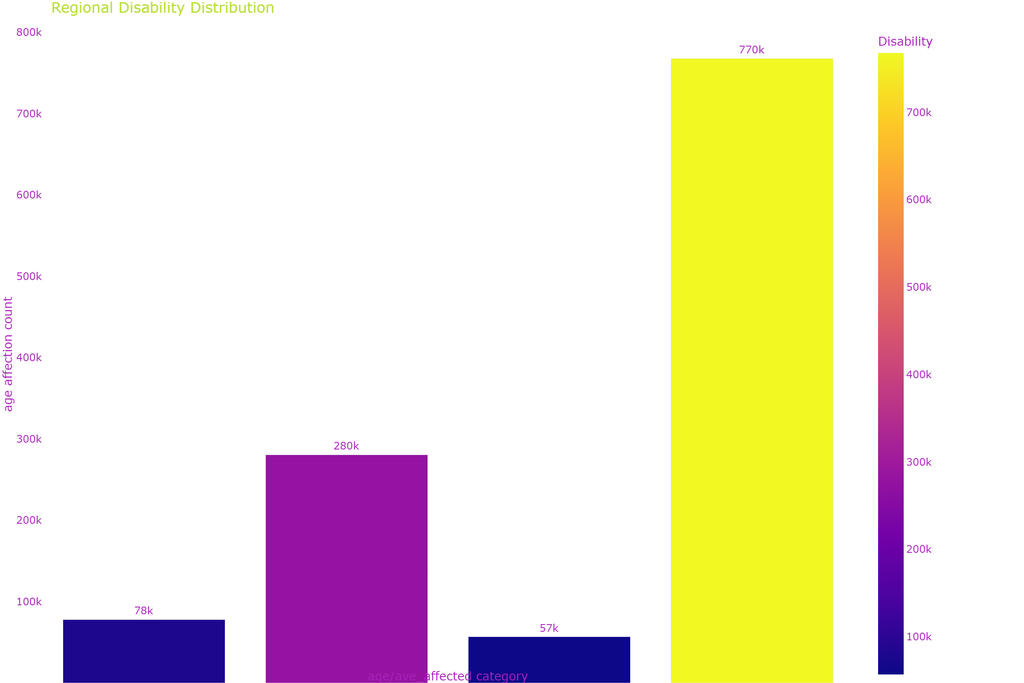

```python
figbar=px.bar(group_age_to_viz,x="age/ave_affected",y="age affection",
       color="age affection",title="Regional Disability Distribution",
       labels={"age/ave_affected":"age/ave_affected category",
               "age affection":"age affection count"},
               text="age affection", color_continuous_scale=colors
               )
figbar.update_traces(texttemplate="%{text:.2s}",textposition="outside")
fig_layout(figbar,viz)
to_image(figbar,"Bar_chart2")
```

##### Scatter

Shows the Distribution Region with disability in Scatter

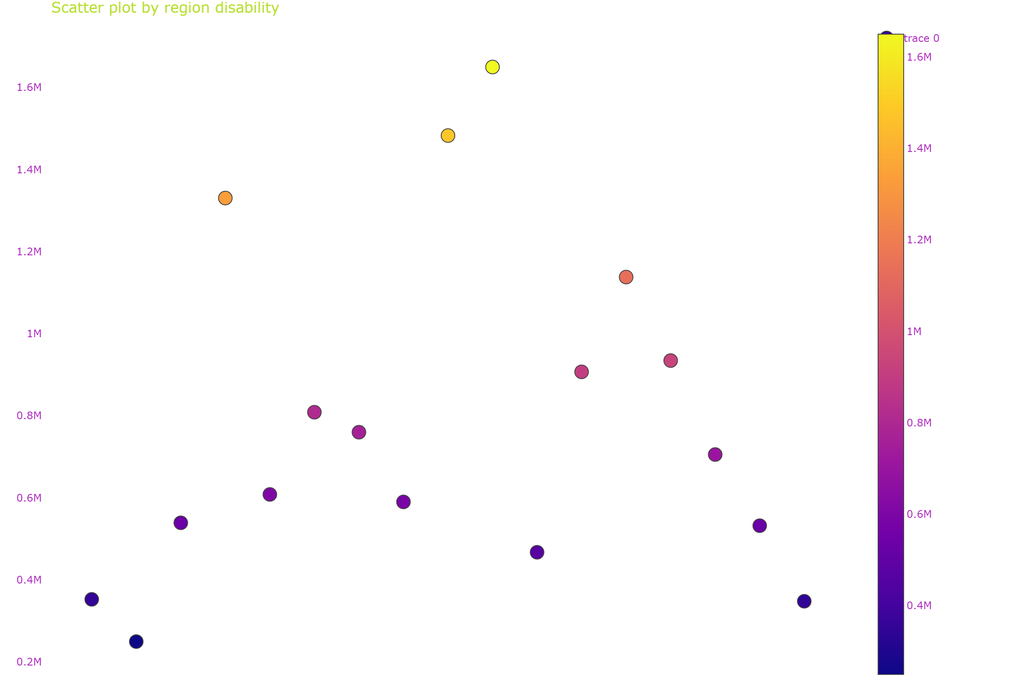

```python
con="Region"
scatter=groupbys(con) #function the i mention earlier for customizing output of charts and plot
figsc=go.Figure()
figsc.add_trace(go.Scatter(x=scatter[con],
                           y=scatter["Household Population 5 Years Old and Over with Functional Difficulty"],
                           mode="markers",  marker_color=scatter["Household Population 5 Years Old and Over with Functional Difficulty"],
                           marker=dict(showscale=True ,colorscale=colors)))
figsc.update_traces(marker_line_width=1,marker_size=16)
figsc.update_layout(title=dict(text="Scatter plot by region disability"))
figsc.update_layout(
    margin=dict(autoexpand=False,r=100,l=50,t=50),showlegend=False,autosize=True
                )
fig_layout(figsc,viz)
to_image(figsc,"Scatter_plot1")
```

Shows the Distribution in Ages columns in Scatter

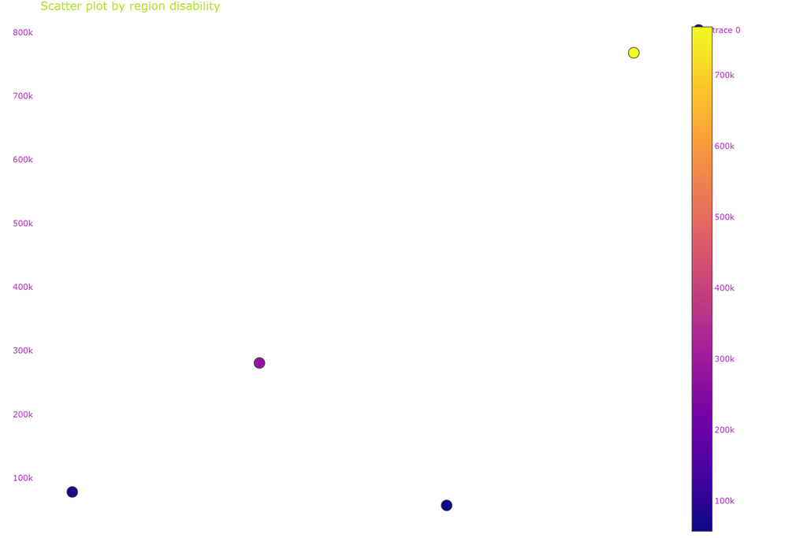

```python
figage=go.Figure()
figage.add_trace(go.Scatter(x=group_age_to_viz["age/ave_affected"],y=group_age_to_viz["age affection"],
        mode="markers",  marker_color=group_age_to_viz["age affection"],
                           marker=dict(showscale=True ,colorscale=colors)
               ))
figage.update_traces(marker_line_width=1,marker_size=16)
figage.update_layout(title=dict(text="Scatter plot by region disability"))
figage.update_layout(
    margin=dict(autoexpand=False,r=100,l=50,t=50),showlegend=False,autosize=True
                )
fig_layout(figage,viz)

to_image(figage,"Scatter_plot2")
```

##### Pie

Shows the Distribution in Gender columns in Pie

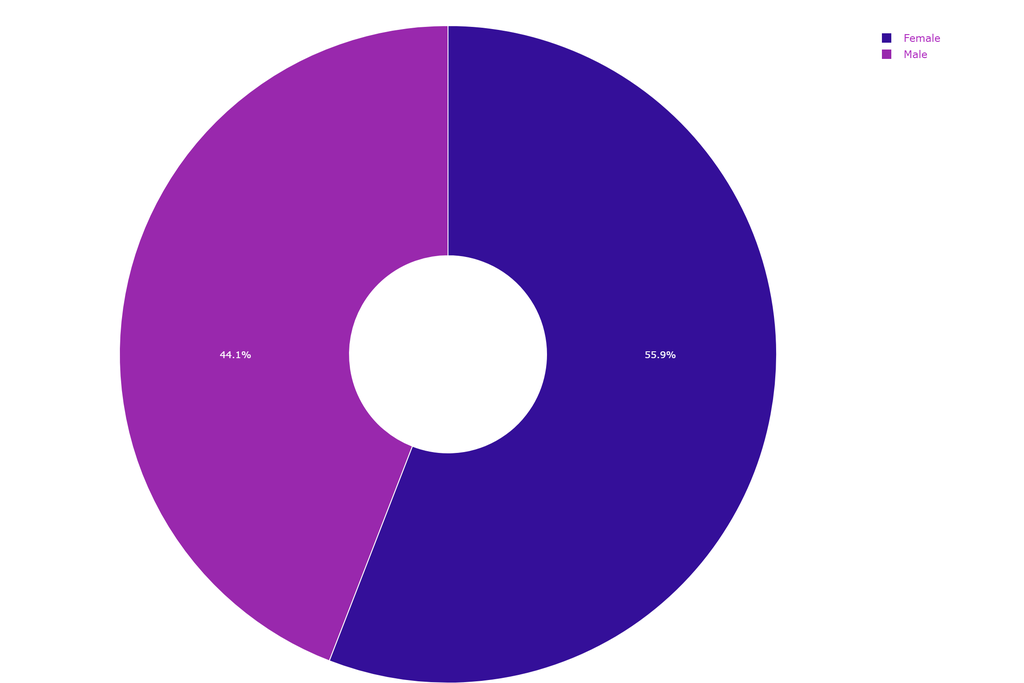

```python
con="Sex"
pie=groupbys(con)
fig=go.Figure()
fig.add_trace(go.Pie(values=pie["Household Population 5 Years Old and Over with Functional Difficulty"],
                           labels=pie[con],insidetextorientation='radial',hole=0.3))
fig.update_traces(hoverinfo='label+value+percent', textinfo='percent', textfont_size=11,
                  marker=dict(colors=["#340f99","#9928ad",], line=dict(color='white',width=1)))
fig_layout(fig,viz)
to_image(fig,"Pie_plot1")
```

Shows the Distribution in Ages columns in Pie

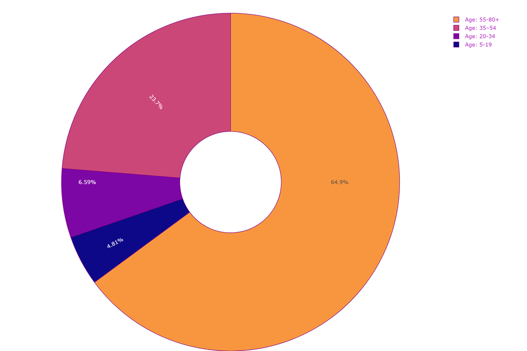

```python
figage = go.Figure() # i cant make the figure have the same name in the same plot  becuase the first one just override the next
figage.add_trace(go.Pie(
    values=age_to_viz["age affection"],
    labels=age_to_viz["age/ave_affected"],
    insidetextorientation='radial',
    hole=0.3,
    marker=dict(colors=colors, line=dict(color='purple', width=1))
))
fig_layout(figage,viz)
to_image(figage,"Pie_plot2")
```

##### whisker

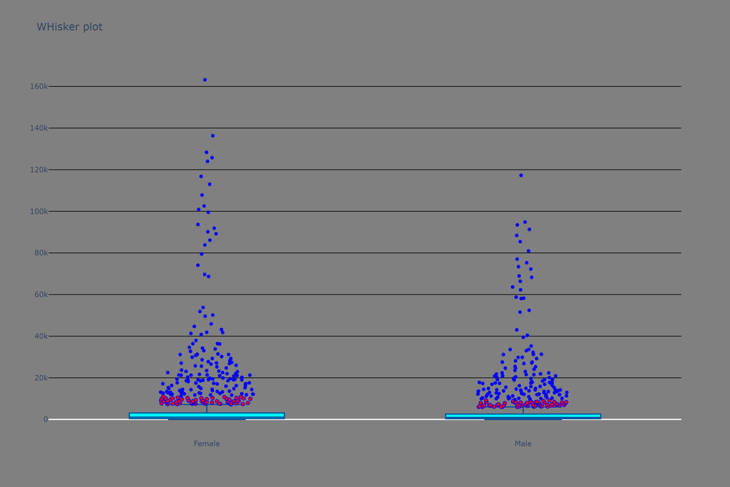

```python
figsex=go.Figure()
figsex.add_traces(go.Box(x=gender_severety["Sex"],y=gender_severety["Household Population 5 Years Old and Over with Functional Difficulty"],
                      boxpoints="suspectedoutliers",marker=dict(color="red",outliercolor='red'),
    line_color='rgb(8,81,156)',
                      jitter=0.6,marker_color="blue",fillcolor="cyan",whiskerwidth=0.5))
figsex.update_layout(title="WHisker plot",yaxis=dict(gridcolor="black",gridwidth=1),paper_bgcolor="gray",plot_bgcolor="gray")
to_image(figsex,"Whisker_plot1")
```

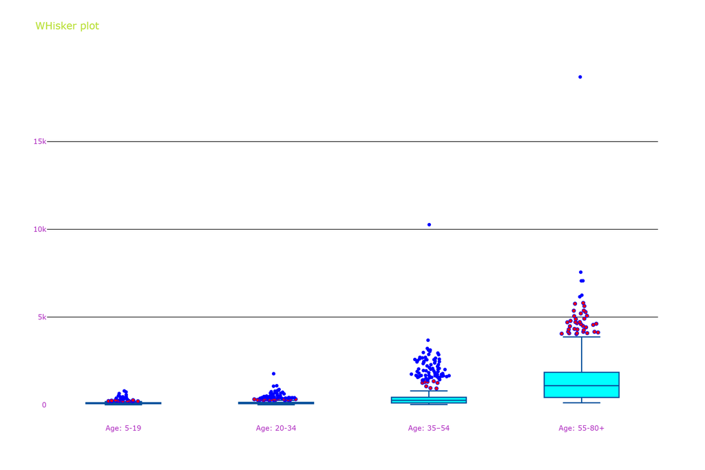

```python
figage=go.Figure()
figage.add_traces(go.Box(x=age_to_viz["age/ave_affected"],y=age_to_viz["age affection"],
                      boxpoints="suspectedoutliers",marker=dict(color="red",outliercolor='red'),
    line_color='rgb(8,81,156)',
                      jitter=0.6,marker_color="blue",fillcolor="cyan",whiskerwidth=0.5))
figage.update_layout(title="WHisker plot",yaxis=dict(gridcolor="black",gridwidth=1),paper_bgcolor="gray",plot_bgcolor="gray")
figage.update_layout(
        title_font=dict(color="#bae03a"),
      font=dict(color="#ab22bd"),
        paper_bgcolor = 'rgba(0,0,0,0)',
        plot_bgcolor = 'rgba(0,0,0,0)')
to_image(figage,"Whisker_plot2")
```

## merge & groupby save

Saving the groupbys and merges as csv for easier access for any one viewing the project and for so i dont have to put group by in app.py

```python
dataset.to_csv("csv/func_dis_dataset.csv",index=False)
total_disability_population.to_csv("csv/groupbys_dataset/total_disability_population.csv",index=False)
age_to_viz.to_csv("csv/groupbys_dataset/age_to_viz.csv",index=False)
gender_serverity_disability.to_csv("csv/groupbys_dataset/gender_serverity_disability.csv",index=False)
age_regional_disibality.to_csv("csv/groupbys_dataset/age_regional_disibality.csv",index=False)
```

wish i didnt have to create this images but i got no choice since i cant find a way to show them to html without doing this if you know how to do it.pls message me at fb [jkian bo](https://www.facebook.com/kian.james.boringot) i would like to talk to someone with passion for data science